# Hashing

Algoritma searching yang ketiga adalah Hashing. Penjelasan algoritma hashing ini akan dibagi menjadi tiga bagian, yaitu :

1. Hashing
2. Fungsi Hash
3. Penanganan Collusion

Pencarian akan lebih **cepat** lagi jika semua data pada list terletak **tepat** berada ditempatnya masing-masing, sehingga pencarian dilakukan hanya dengan **satu kali** proses perbandingan saja. Algoritma ini dikenal dengan nama **Hashing**. Di dalam algoritma hashing ini terdapat beberapa istilah dasar sebagai berikut:

Hashing dalam Struktur Data Hashing adalah teknik yang digunakan dalam struktur data yang secara efisien menyimpan dan mengambil data dengan cara yang memungkinkan akses cepat.

- Hashing melibatkan pemetaan data ke indeks tertentu dalam tabel hash (array item) menggunakan fungsi hash . Ini memungkinkan pengambilan informasi yang cepat berdasarkan kuncinya.
- Keunggulan hashing adalah kita dapat melakukan ketiga operasi (pencarian, penyisipan, dan penghapusan) dalam waktu O(1) rata-rata.
- Hashing terutama digunakan untuk mengimplementasikan sekumpulan item yang berbeda (hanya kunci) dan kamus (pasangan kunci-nilai). Berikut contoh hashing menggunakan metode modulo. Fungsi hash H(x) = x % 10mengubah bilangan besar apa pun menjadi nilai yang lebih kecil antara 0 dan 9.

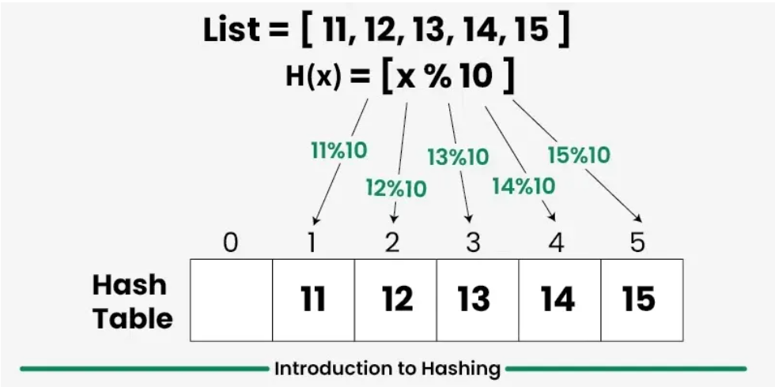

- **Hash Table**, yaitu sebuah tempat penyimpanan data, yang dibuat sedemikian rupa, sehingga dapat memudahkan pencarian. Tipe data list di python dapat digunakan untuk merepresentasikan hash table
- **slot**, yaitu posisi (indeks) yang terdapat pada hash table sebagai tempat penyimpanan setiap data. Karena slot berfungsi seperti halnya indeks, maka nilai slot adalah nilai integer mulai dari nol sampai dengan ukurang dari hash table, misalkan slot 0, slot 1, slot 2, .... , slot . Contoh hash table dan slot yang masih kosong dapat dilihat pada Gambar 1. Pada Gambar tersebut terdapat sebuah hash table dengan 11 slot kosong :

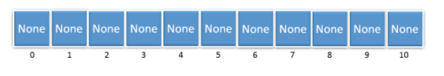

- **Hash function**, yaitu suatu fungsi yang memetakan antara data dengan slot di dalam hash table

### Fungsi Hash

Hash function ini memegang peranan penting dalam algoritma hashing, dengan hash function ini, data didalam list disusun berdasarkan nilai hash, dan pencarian data dilakukan berdasarkan **nilai hash** dari hash function ini. Hash function memiliki parameter nilai data (baik data yang akan disusun didalam list ataukah data yang akan dicari), dan mengembalikan nilai integer (nilai hash) yang merupakan representasi dari **nomor slot**.

Berikut contoh data dan nilai hash, dengan fungsi modulus 11 (ukuran tabel).

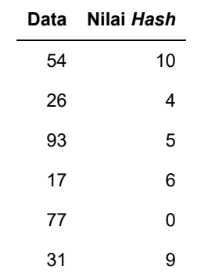

Sehingga dengan data dan nilai hash tersebut, maka representasi data di dalam hash table, dapat dilihat pada Gambar 2 berikut.

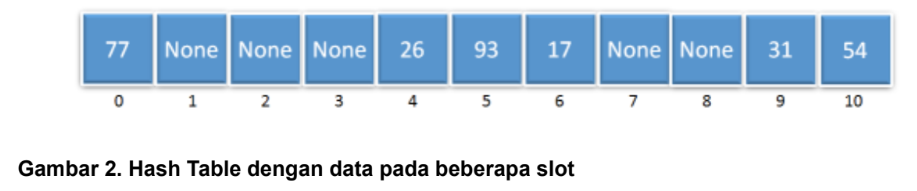

Setelah semua data berada di dalam hash table, maka dapat dihitung Load factor dari hash table, yang merupakan presentasi pemakaian hash tabel, dengan menggunakan persamaan λ = jumlahData / ukuranTabel

Pencarian data dilakukan hanya dengan cara menghitung function hash berdasarkan data tersebut, dan nilai balik data tersebut merupakan index atau slot dari data di dalam list, kemudian dilakukan pengecekan keberadaan data tersebut hanya dengan satu kali perbandingan saja.

Berikut adalah fungsi-fungsi yang diperlukan untuk algoritma hashing ini, antara lain :

- hash function (gunakan remainder function, yaitu data dimodulus dengan 11), nilai balik merupakan nilai hash
- createHashTable, untuk membuat hash table, dengan inisialisasi semua slot berisi 'none'
- putData, yaitu menyusun data ke dalam hash table, berdasarkan nilai hash yang dihasilkan
- searchHash, argumen merupakan data yang dicari, dan nilai balik berupa True or False, yaitu apakah data ditemukan di dalam hash table

```python
def remainderFunction (data,num):
    return (data%num)
def createHashTable(num):
    temp=[]
    for i in range(num):
        temp.append('none')
    return(temp)
def putData(data,table):
    for i in range(len(data)):
        ind=remainderFunction(data[i],len(table))
        table[ind]=data[i]
    return(table)
def searchHash(data,table):
    hashVal=remainderFunction(data,len(table))
    if data==table[hashVal]:
        return True
    else:
        return False
```

```python
a=[54, 26, 93, 17, 77, 31]
hashTable=createHashTable(11)
print(hashTable)
```

```
['none', 'none', 'none', 'none', 'none', 'none', 'none', 'none', 'none', 'none', 'none']
```

```python
hashTable=putData(a,hashTable)
print(hashTable)
```

```
[77, 'none', 'none', 'none', 26, 93, 17, 'none', 'none', 31, 54]
```

```python
searchHash(93,hashTable)
```

```
True
```

Permasalahan timbul ketika terdapat data dengan nilai hash yang sama, sehingga akan mengacu pada nomor slot yang sama. Contoh pada data sebelumnya, terdapat data 44, dengan menggunakan **Remainder hash function** maka nilai hash sama dengan 0, sedangkan slot 0, sudah ditempati oleh data 77. Permasalahan ini dikenal dengan **collusion**.

Untuk meminimalkan terjadinya collusion ini, diperlukan adanya **perfect hash function**, yaitu suatu hash function yang memetakan data tepat ke slot yang unik. Sehingga sebuah slot hanya ditempati oleh sebuah data saja. Tujuan dari **perfect hash function** ini meminimalkan terjadinya **collusion**. Contoh perfect hash function adalah **mid-square method**, yaitu kuadratkan nilai data, kemudian ambil bagian tertentu dari data tersebut. Misalkan terdapat data 35, maka 35*2 = 1225 , dan character yang terletak di bagian tengah dari 1225 adalah '22', kemudian lakukan perhitungan modulus dengan ukuran table, misalkan 22%11, yaitu 0

```python
def mid_square_hash(key, num_digits):
    squared_key = key ** 2
    str_sq = str(squared_key)

    if len(str_sq) < num_digits:
        str_sq = str_sq.zfill(num_digits)

    start_index = (len(str_sq) - num_digits) // 2
    end_index = start_index + num_digits

    middle_digits = str_sq[start_index:end_index]

    return int(middle_digits)

keys = [113, 45, 992, 12]
jumlah_digit = 2

for k in keys:
    kuadrat = k ** 2
    nilai_hash = mid_square_hash(k, jumlah_digit)
    print(f"Key: {k} -> Kuadrat: {kuadrat} -> Nilai Hash: {nilai_hash}")
```

```
Key: 113 -> Kuadrat: 12769 -> Nilai Hash: 27
Key: 45 -> Kuadrat: 2025 -> Nilai Hash: 2
Key: 992 -> Kuadrat: 984064 -> Nilai Hash: 40
Key: 12 -> Kuadrat: 144 -> Nilai Hash: 14
```

```python
size = 5
table = []

for i in range(size):
    table.append([])

def hash_function(key):
    return key % size

# create
def insert(key):
    index = hash_function(key)
    table[index].append(key)
    print(f"Data {key} ditambahkan di index {index}")


# read/ Search
def search(key):
    index = hash_function(key)
    for data in table[index]:
        if data == key:
            print(f"Data {key} ditemukan di index {index}")
            return
    print(f"Data {key} tidak ditemukan")


#upgrade
def update(old, new):
    index = hash_function(old)
    for data in table[index]:
        if data == old:
            table[index].remove(old)
            insert(new)
            print(f"Data {old} diganti menjadi {new}")
            return
    print(f"Data {old} tidak ditemukan, tidak bisa diupdate")

#delete
def delete(key):
    index = hash_function(key)
    for data in table[index]:
        if data == key:
            table[index].remove(key)
            print(f"Data {key} berhasil dihapus")
            return
    print(f"Data {key} tidak ditemukan")

def display():
    print("\nIsi Hash Table:")
    for i in range(size):
        print(f"Index {i}: {table[i]}")


insert(10)
insert(20)
insert(15)
insert(7)

display()

search(20)

update(20, 25)
display()

delete(10)
display()
```

```
Data 10 ditambahkan di index 0
Data 20 ditambahkan di index 0
Data 15 ditambahkan di index 0
Data 7 ditambahkan di index 2

Isi Hash Table:
Index 0: [10, 20, 15]
Index 1: []
Index 2: [7]
Index 3: []
Index 4: []
Data 20 ditemukan di index 0
Data 25 ditambahkan di index 0
Data 20 diganti menjadi 25

Isi Hash Table:
Index 0: [10, 15, 25]
Index 1: []
Index 2: [7]
Index 3: []
Index 4: []
Data 10 berhasil dihapus

Isi Hash Table:
Index 0: [15, 25]
Index 1: []
Index 2: [7]
Index 3: []
Index 4: []
```

3. MidSquareMethod(Function Hash)

```python
def hash_tengah(angka, ukuran):
    hasil_kuadrat = angka * angka
    teks = str(hasil_kuadrat)
    tengah = len(teks) // 2
    if len(teks) >= 2:
        ambil = teks[tengah-1:tengah+1]
    else:
        ambil = teks
    return int(ambil) % ukuran

ukuran_tabel = 10
data_angka = [12, 45, 123, 56]
for angka in data_angka:
    print("Angka", angka, " Hash:", hash_tengah(angka, ukuran_tabel))
```

```
Angka 12  Hash: 4
Angka 45  Hash: 2
Angka 123  Hash: 1
Angka 56  Hash: 3
```